# Project: Analyze USA Youtube Trending Videos

- Introduction
- Explanatory Data Analysis

## Introduction

YouTube (the world-famous video sharing website) maintains a list of the top trending videos on the platform. According to Variety magazine, “To determine the year’s top-trending videos, YouTube uses a combination of factors including measuring users interactions (number of views, shares, comments, and likes). Note that they’re not the most-viewed videos overall for the calendar year”. Top performers on the YouTube trending list are music videos (such as the famously virile “Gangam Style”), celebrity and/or reality TV performances, and the random dude-with-a-camera viral videos that YouTube is well-known for.

The given data set has data for 5 different regions. This report is a work on USA dataset which has a daily record of the top trending YouTube videos from November 2017 to June 2018.

Here we will mainly focus on what categories make most top trending videos and how are they received by the users(based on likes, dislikes, and comments)

The key insights we gain from the observations ahead are how different categories perform over months and days and which hour of the day there are most number of trending videos published. One other main insight we get from the observations is the category which published more trending videos is not the same as the category which has more likes, views and comments.

## Explanatory Data Analysis

The coming plot will give us information about the spread of our data variables likes, views, dislikes, comment_count.

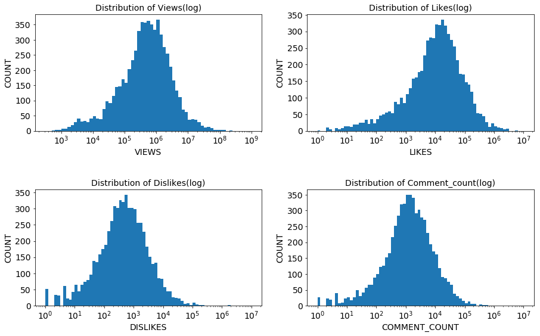

```python
#figsize
plt.figure(figsize=[15,9])
#subplot spacing
plt.subplots_adjust(hspace = 0.5)


# first subplot shows the distribution of views
plt.subplot(2,2,1)
bins = 10 ** np.arange(2.5, 9+0.1, 0.1)
plt.hist(data = df, x = 'views', bins = bins);
plt.xscale('log');
plt.xticks(fontsize = 14)
plt.yticks(fontsize = 14)
plt.ylabel('COUNT', fontsize = 14)
plt.xlabel('VIEWS', fontsize = 14)
plt.title('Distribution of Views(log)', fontsize = 14);

# second subplot shows the distribution of likes
plt.subplot(2,2,2)
bins = 10 ** np.arange(0, 7+0.1, 0.1)
plt.hist(data = df, x = 'likes', bins = bins);
plt.xscale('log');
plt.xticks(fontsize = 14)
plt.yticks(fontsize = 14)
plt.ylabel('COUNT',fontsize = 14)
plt.xlabel('LIKES',fontsize = 14)
plt.title('Distribution of Likes(log)',fontsize = 14);

# third subplot shows the distribution of dislikes
plt.subplot(2,2,3)
bins = 10 ** np.arange(0, 7+0.1, 0.1)
plt.hist(data = df, x = 'dislikes', bins = bins);
plt.xscale('log');
plt.xticks(fontsize = 14)
plt.yticks(fontsize = 14)
plt.ylabel('COUNT',fontsize = 14)
plt.xlabel('DISLIKES',fontsize = 14)
plt.title('Distribution of Dislikes(log)',fontsize = 14);

# first subplot shows the distribution of comments count
plt.subplot(2,2,4)
bins = 10 ** np.arange(0, 7+0.1, 0.1)
plt.hist(data = df, x = 'comment_count', bins = bins);
plt.xscale('log');
plt.xticks(fontsize = 14)
plt.yticks(fontsize = 14)
plt.ylabel('COUNT',fontsize = 14)
plt.xlabel('COMMENT_COUNT',fontsize = 14)
plt.title('Distribution of Comment_count(log)',fontsize = 14);
```

Previous plots show us the distribution of views, likes, dislikes, number of comments on top trending videos. Lets take a look at them. Here I have used a log scale to view the distribution of data to get a better understanding of the distribution. All the plots are right skewed as mean of data is greater than median of data but the plots are considered normally distributed as we are seeing them on log transformation and likes, dislikes, comments count have some outliers.

## Lets look at the relation between the variables in the data.

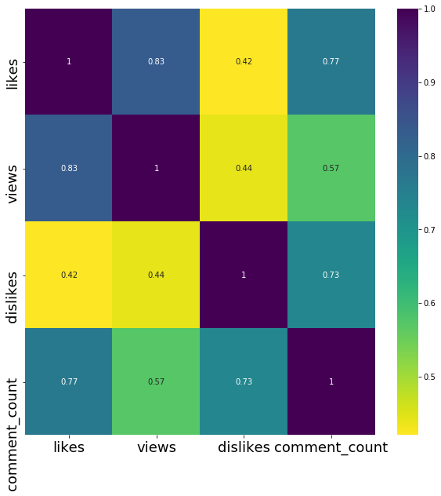

```python
#figsize
plt.figure(figsize = [10,10])
#plot
sns.heatmap(df[['likes','views','dislikes','comment_count']].corr(), annot = True,cmap = 'viridis_r');
plt.xticks(fontsize = 18);
plt.yticks(fontsize = 18);
```

The previous plot gives us a quick view on how our variables likes,dislikes,comments count and views are linked to each other. From the plot we can see that the highest corelation is between views and likes whereas the lowest corelation is between likes and dislikes.

We have categories for all the published trending videos. Lets see which category published the most videos.

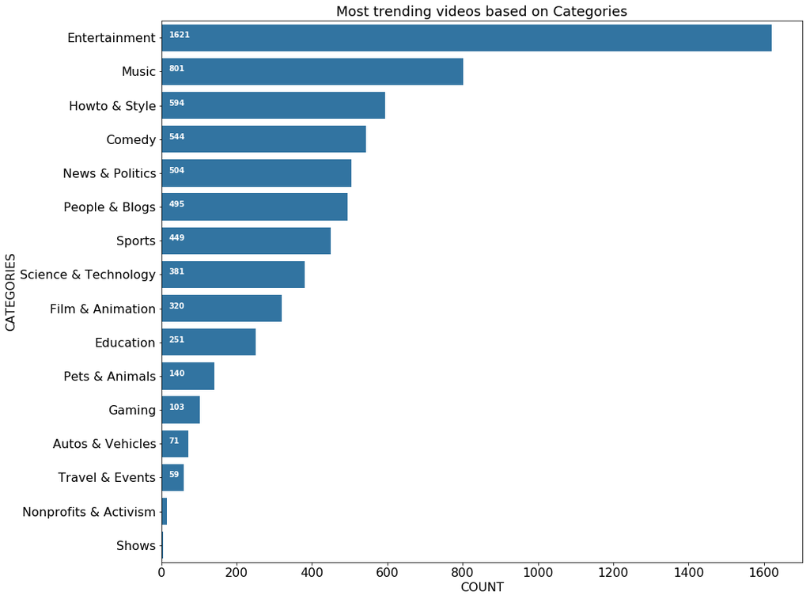

```python
#fig size
plt.figure(figsize = (15,13))
#color
base_color = sns.color_palette()[0]
#setting the categories in order
category = df['category_name'].value_counts()
category_order = category.index
#plot
sns.countplot(y = 'category_name', data = df, order = category_order, color = base_color);
#axis and title
plt.xticks(fontsize=16);
plt.yticks(fontsize=16);

plt.ylabel('CATEGORIES', fontsize=16)
plt.xlabel('COUNT', fontsize=16)
plt.title('Most trending videos based on Categories', fontsize=18);

# loop through to show values in plot
for a,b in enumerate(category):
    plt.text(20, a, b, color = 'w', weight = 'heavy')
```

Here in the previous plot we see that videos which fall into entertainment category have the most published trending videos, followed by Music and Howto & Style categories. The videos which fall into Nonprofits & Activism, Shows have very few videos which make into trending videos zone.

## From here on we will analyzing the performance of top three categories.

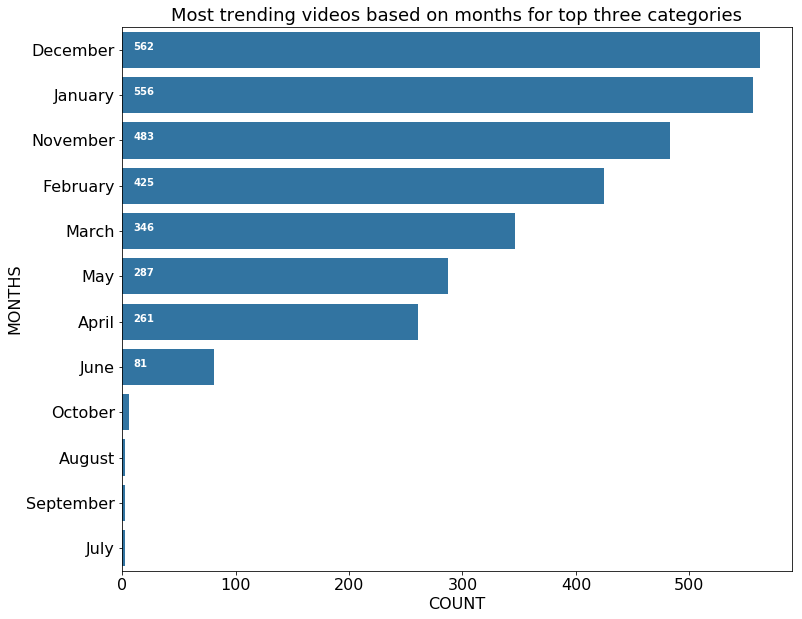

```python
#figsize
plt.figure(figsize = (12,10))
#set months in order of most published videos
month = df_top3_cat['month'].value_counts()
month_order = month.index
#plot data
ax = sns.countplot(y = 'month', data = df_top3_cat, order = month_order, color = base_color);
#axis and title
plt.xticks(fontsize=16);
plt.yticks(fontsize=16);

plt.xlabel('COUNT', fontsize=16)
plt.ylabel('MONTHS', fontsize=16)
plt.title('Most trending videos based on months for top three categories', fontsize=18);

# loop through to show values in plot
for a,b in enumerate(month):
    plt.text(10,a,b,color = 'w', weight = 'heavy')
```

The previous plot shows which month of the year posted most trending videos based on top three categories. We can see that December has the most published videos and July, August, Spetember has least published videos. Lets see which weekday has most published videos

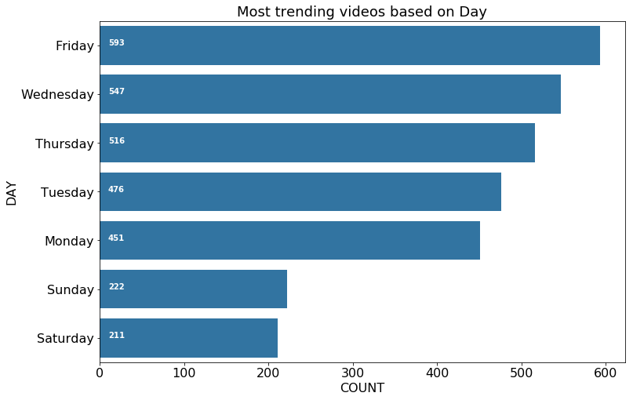

```python
#figsize
plt.figure(figsize = (12,8))
#set days based on most videos publised in order
day = df_top3_cat['day'].value_counts()
day_order = day.index
#plot the data
sns.countplot(y = 'day', data = df_top3_cat, order = day_order, color = base_color);
# axis and titles
plt.xticks(fontsize = 16);
plt.yticks(fontsize = 16);
plt.xlabel('COUNT', fontsize = 16)
plt.ylabel('DAY', fontsize = 16)
plt.title('Most trending videos based on Day', fontsize = 18);

# loop through to show values in plot
for a,b in enumerate(day):
    plt.text(10,a,b,color = 'w', weight = 'heavy')
```

Here the plot shows which weekday posted most trending videos based on top 3 categories. We can see that Friday has the most published videos and Saturday has least published videos. Now lets see which hour of the day has most published videos

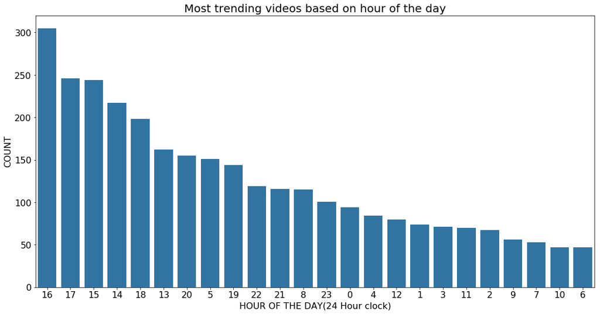

```python
#figsize
plt.figure(figsize = (18,9))

#set hour of day based on most videos publised in order
time = df_top3_cat['hour'].value_counts()
time_order = time.index
#plot the data
sns.countplot(x = 'hour', data = df_top3_cat, order = time_order, color = base_color);
#axis and title
plt.xticks(fontsize = 16);
plt.yticks(fontsize = 16);
plt.ylabel('COUNT', fontsize = 16)
plt.xlabel('HOUR OF THE DAY(24 Hour clock)', fontsize = 16)
plt.title('Most trending videos based on hour of the day', fontsize = 20);
```

Here the plot shows which hour of the day posted most trending videos based on top 3 categories. We can see that 4 in the evening hour has the most published videos and 6 and 10 in the morning hours has least published videos. The coming plots shows trend lines of likes, views, dislikes, comment counts on monthly basis.

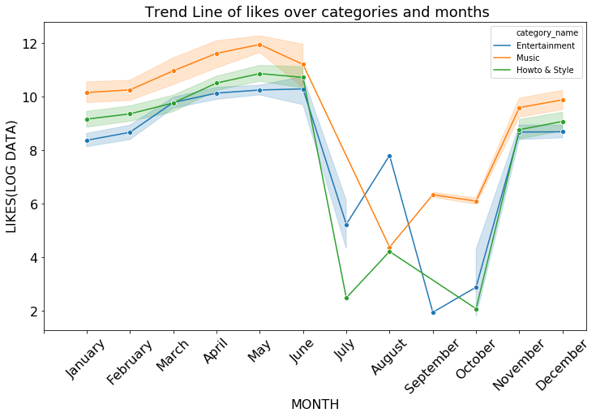

```python
plt.figure(figsize=[12,7])

y1 = np.log(df_top3_cat['likes']+1)

sns.lineplot(y = y1, x = 'month_num', hue = 'category_name', data = df_top3_cat, marker = 'o')
#set axis labels and title
plt.xticks(np.arange(13), calendar.month_name[0:13], rotation=45, fontsize = 16)
plt.yticks(fontsize = 16)
plt.ylabel('LIKES(LOG DATA)', fontsize = 16)
plt.xlabel('MONTH', fontsize = 16)
plt.title(' Trend Line of likes over categories and months', fontsize = 18);
```

From the previous plot we can see the trend lines of Entertainment, Music and Howto & Style. The trend line for all the categories shows that the likes increase from January to May and then the likes number falls from June and shows a lot of flutuation between June to October and then they tend to increase in winter(November and December). In the coming plot lets check the trend lines for views.

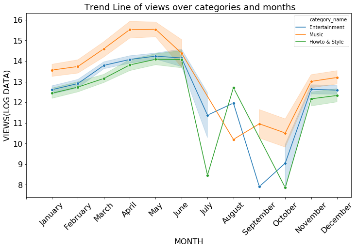

```python
plt.figure(figsize=[12,7])

y1 = np.log(df_top3_cat['views']+1)

sns.lineplot(y = y1, x = 'month_num', hue = 'category_name', data = df_top3_cat, marker = 'o' )
#set axis labels and title
plt.xticks(np.arange(13), calendar.month_name[0:13], rotation=45, fontsize = 16)
plt.yticks(fontsize = 16);
plt.ylabel('VIEWS(LOG DATA)', fontsize = 16)
plt.xlabel('MONTH', fontsize = 16)
plt.title(' Trend Line of views over categories and months', fontsize = 18);
```

From the previous plot we can see the trend lines of Entertainment, Music and Howto & Style for views data. The trend line for all the categories shows that the views increase from January to May and tend to falls from June and shows a lot of flutuation between June to October and then they tend to increase in winter(November and December). In the coming plot lets check the trend lines for dislikes.

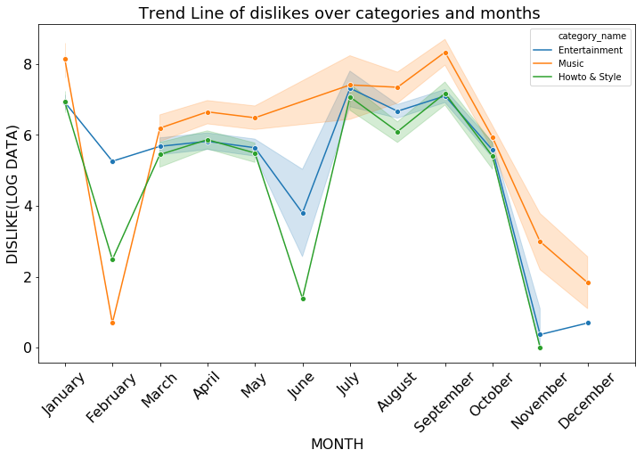

```python
plt.figure(figsize=[12,7])

y1 = np.log(df_top3_cat['dislikes']+1)
sns.lineplot(y = y1, x = 'month', hue = 'category_name', data = df_top3_cat, marker = 'o')
#set axis labels and title
plt.xticks(np.arange(13), calendar.month_name[1:13], rotation=45, fontsize = 16)
plt.yticks(fontsize = 16);
plt.ylabel('DISLIKE(LOG DATA)', fontsize = 16)
plt.xlabel('MONTH', fontsize = 16)
plt.title(' Trend Line of dislikes over categories and months', fontsize = 18);
```

From the previous plot we can see the trend lines of Entertainment, Music and Howto & Style for dislikes. The trend line of How to Style and Entertainment show lot of fluctuations in the trend line with decrease in dislikes in february, June and in Winter. The trend line for music also has fluctuations but its shows steady increase from march to september and tends to decrease in Winter. In the coming plot lets check the trend lines for comments count.

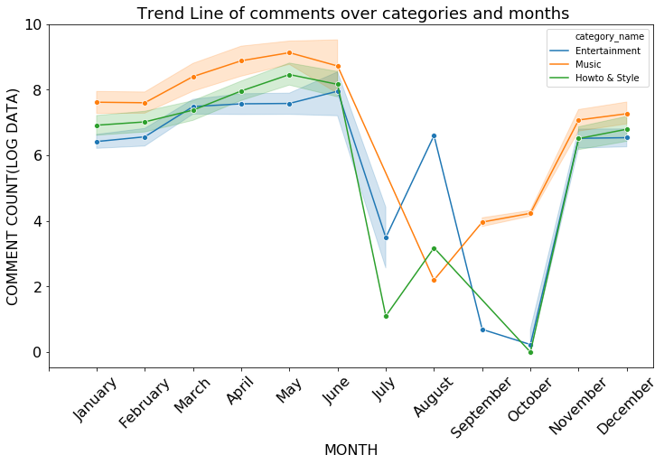

```python
plt.figure(figsize=[12,7])

y1 = np.log(df_top3_cat['comment_count']+1)
sns.lineplot(y = y1, x = 'month_num', hue = 'category_name', data = df_top3_cat, marker = 'o')
#set axis labels and title
plt.xticks(np.arange(13), calendar.month_name[0:13], rotation=45, fontsize = 16)
#plt.xticks(rotation=45, fontsize = 16);
plt.yticks(fontsize = 16);

plt.ylabel('COMMENT COUNT(LOG DATA)', fontsize = 16)
plt.xlabel('MONTH', fontsize = 16)
plt.title(' Trend Line of comments over categories and months', fontsize = 18);
```

From the previous plot we can see the trend lines of Entertainment, Music and Howto & Style for comments count. The trend line for music shows steady increase from January to May and starts to decrease from june and again inceases from August. The trend lines for Entertainment and How to style also tend to increase from January to May and starts dropping from June and show lot of fluctuations between july and october and tend to increase in winter(October - December). Lets now see which categories have most likes, views, dislikes, comments

[figure not shown]

```python
#figsize
plt.figure(figsize = (15,15))
plt.subplots_adjust(hspace = 0.4)

#plot the data
plt.subplot(4,1,1)
sns.barplot(x = 'total_views',y = 'category', data = df_sum_views,
            order = ['Music', 'Entertainment', 'Howto & Style'], color = base_color);
# axis and titles

plt.xticks(fontsize = 16);
plt.yticks(fontsize = 16);
plt.xlabel('VIEWS', fontsize = 16)
plt.ylabel('CATEGORY', fontsize = 16)
plt.title('Total Number of viwes of categories', fontsize = 18);

# loop through to show values in plot
for a,b in enumerate(df_sum_views.total_views):
    plt.text(10,a,b,color = 'w', weight = 'heavy')

#plot the data
plt.subplot(412)
sns.barplot(x = 'total_likes',y = 'category', data = df_sum_likes,
            order = ['Music', 'Entertainment', 'Howto & Style'], color = base_color);
# axis and titles

plt.xticks(fontsize = 16);
plt.yticks(fontsize = 16);
plt.xlabel('LIKES', fontsize = 16)
plt.ylabel('CATEGORY', fontsize = 16)
plt.title('Total Number of likes of categories', fontsize = 18);

# loop through to show values in plot
for a,b in enumerate(df_sum_likes.total_likes):
    plt.text(10,a,b,color = 'w', weight = 'heavy')


#plot the data
plt.subplot(413)
sns.barplot(x = 'total_dislikes',y = 'category', data = df_sum_dislikes,
            order = [ 'Entertainment', 'Music','Howto & Style'], color = base_color);
# axis and titles

plt.xticks(fontsize = 16);
plt.yticks(fontsize = 16);
plt.xlabel('DISLIKES', fontsize = 16)
plt.ylabel('CATEGORY', fontsize = 16)
plt.title('Total Number of dislikes of categories', fontsize = 18);

# loop through to show values in plot
for a,b in enumerate(df_sum_dislikes.total_dislikes):
    plt.text(10,a,b,color = 'w', weight = 'heavy')


#plot the data
plt.subplot(414)
sns.barplot(x = 'total_comment_count',y = 'category', data = df_sum_comment_count,
            order = ['Music', 'Entertainment', 'Howto & Style'], color = base_color);
# axis and titles

plt.xticks(fontsize = 16);
plt.yticks(fontsize = 16);
plt.xlabel('COMMENT COUNT', fontsize = 16)
plt.ylabel('CATEGORY', fontsize = 16)
plt.title('Total Number of comment_count of categories', fontsize = 18);

# loop through to show values in plot
for a,b in enumerate(df_sum_comment_count.total_comment_count):
    plt.text(10,a,b,color = 'w', weight = 'heavy')
```

From the previous plot we can see that though the Entertainment category has most number of published videos, the Music category has most number of likes, views and comments followed by Entertainment and How to Style. When it comes to dislikes Entertainment category has most number of dislikes followed by Music and How to Style. Let us now see the corelation of the variables over top 3 categories.

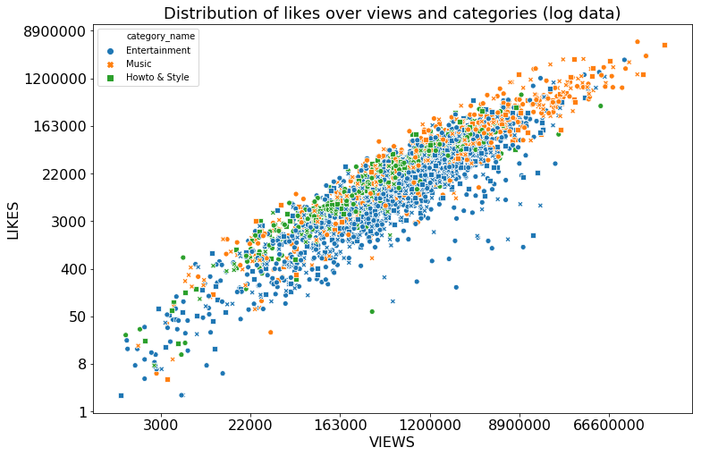

```python
plt.figure(figsize = [12,8])

x1 = np.log(df_top3_cat['views'])
y1 = np.log(df_top3_cat['likes'])



sns.scatterplot(data = df_top3_cat, x = x1, y = y1, hue = 'category_name', style = 'category_name')
#set axis labels and title

ticks = [8,10,12,14,16,18]
labels = [3000,22000,163000,1200000,8900000,66600000]
plt.xticks(ticks,labels, fontsize = 16)

ticks_y = [0,2,4,6,8,10,12,14,16]
labels_y = [1,8,50,400,3000,22000,163000,1200000,8900000]
plt.yticks(ticks_y, labels_y, fontsize = 16);

plt.xlabel('VIEWS', fontsize = 16)
plt.ylabel('LIKES', fontsize = 16)
plt.title('Distribution of likes over views and categories (log data)', fontsize = 18);
```

The previous plot shows us that views and likes have a positive and strong co relation between them over the top three categories.

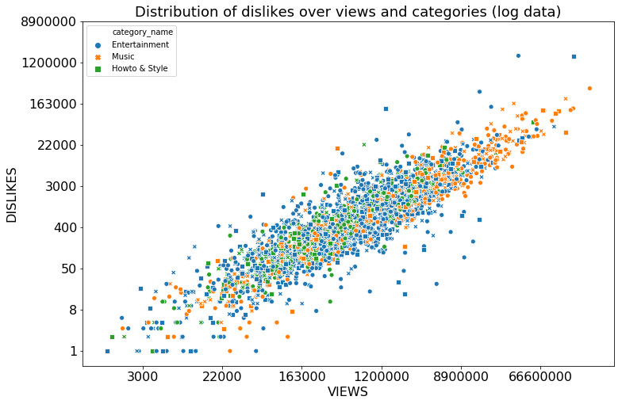

```python
plt.figure(figsize = [12,8])

x1 = np.log(df_top3_cat['views'])
y1 = np.log(df_top3_cat['dislikes'])

sns.scatterplot(data = df_top3_cat, x = x1, y = y1, hue = 'category_name', style = 'category_name')
#set axis labels and title
ticks = [8,10,12,14,16,18]
labels = [3000,22000,163000,1200000,8900000,66600000]
plt.xticks(ticks,labels, fontsize = 16)

ticks_y = [0,2,4,6,8,10,12,14,16]
labels_y = [1,8,50,400,3000,22000,163000,1200000,8900000]
plt.yticks(ticks_y, labels_y, fontsize = 16);

plt.xlabel('VIEWS', fontsize = 16)
plt.ylabel('DISLIKES', fontsize = 16)
plt.title('Distribution of dislikes over views and categories (log data)', fontsize = 18);
```

The previous plot shows us that views and dislikes have a proper positve co relation between them over the top three categories but not as strong as views and likes.

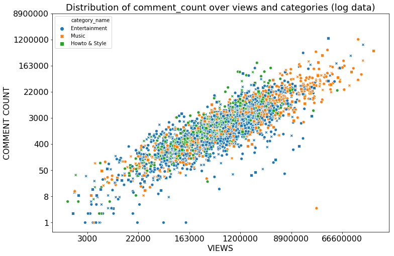

```python
plt.figure(figsize = [12,8])

x1 = np.log(df_top3_cat['views'])
y1 = np.log(df_top3_cat['comment_count'])

sns.scatterplot(data = df_top3_cat, x = x1, y = y1, hue = 'category_name', style = 'category_name')
#set axis labels and title
ticks = [8,10,12,14,16,18]
labels = [3000,22000,163000,1200000,8900000,66600000]
plt.xticks(ticks,labels, fontsize = 16)

ticks_y = [0,2,4,6,8,10,12,14,16]
labels_y = [1,8,50,400,3000,22000,163000,1200000,8900000]
plt.yticks(ticks_y, labels_y, fontsize = 16);

plt.xlabel('VIEWS', fontsize = 16)
plt.ylabel('COMMENT COUNT', fontsize = 16)
plt.title('Distribution of comment_count over views and categories (log data)', fontsize = 18);
```

The previous plot shows us that views and comments_count also have a positive but weaker co relation between them over the top three categories.

## CONCLUSION

Here in this presentation I have analysed variables of full data, then I performed further analysis on variables based on top three categories data. Here are the key insights from the analysis and Visualizations.

- Views and likes have highest corelation where as likes and dislikes have the lowest corelation between them.
- We found that 'Entertainment' category has most published trending videos with a count of 1621 followed by 'Music' with a count of 801, 'How to Style' with a count of 594 and 'shows' category has the least published trending videos with a count of 4.
- Based on the data of top three categories December month has most published videos with a count of 562 where as July has the least published videos with a count of 3.
- Based on the data from the top three categories Friday has the most published trending videos with a count of 593 and saturday has the least published trending videos with a count of 211